# Data Base design

## Contributions

| Person | Short name | Contribution |
| --- | --- | --- |
| Adarsh Vulli | ad | Creating the databse --> applying the constraints on the columns and basic data processing and inserting the data into the database |
| Sarah Dias Barreto | sdb | Wrote queries that will be used for analyzing the inventory and building dashboards --> Created Visualizations |
| Nainesh Rathod | nr | Worked on creating few visualizations that can be used to present on the site |

# Connecting to MongoDB using PyMongo

To connect to MongoDB and work with data using Python, we will be installing Pymongo driver.

The easiest way to install the driver is through the pip package management system. Execute the following on a command line or Anaconda Prompt :

Command line:  
python -m pip install pymongo

Anaconda Prompt:

pip install pymongo

pip3 install 'pymongo[srv]'

```python
! pip install pymongo  # ad
! pip3 install 'pymongo[srv]'
```

[output not shown]

Once PyMongo is installed we can write our first application that will return information about the MongoDB server. In your Python development environment or from a text editor enter the following code.

```python
#ad
import warnings
warnings.filterwarnings('ignore')
```

```python
#ad
import pymongo # ad
from pprint import pprint
# connect to MongoDB, change the << MONGODB URL >> to reflect your own connection string
client = pymongo.MongoClient("mongodb+srv://avulli:root@cluster0.hnq2erb.mongodb.net/")
```

### Exploring Collections and Documents

A collection in MongoDB is a container for documents. A database is the container for collections. Some of the advantages of storing data in documents are dynamic & flexible schema and the ability to store arrays can be seen from our simple Python scripts.

##### Connecting to a specific Database in our cluster.

```python
#ad
# alternative
db = client.Project
#collection = db.video # or db['video']
```

```python
#ad
#connecting to database "video"
db = client.Project  # or client['video']
# Issue the serverStatus command and print the results
serverStatusResult=db.command("serverStatus")
pprint(serverStatusResult)
```

```
{'$clusterTime': {'clusterTime': Timestamp(1712588743, 13),
                  'signature': {'hash': b'Lc\xde\xd11\xa2\x8c\xf8c!\xf6\xf3'
                                        b'R2\xa0n\xbc\xd7\xd1\x17',
                                'keyId': 7292016679402340354}},
 'asserts': {'msg': 0, 'regular': 0, 'rollovers': 0, 'user': 0, 'warning': 0},
 'atlasVersion': {'gitVersion': '73cdc4d19b985b4c4644edab14770e73d130bfa2',
                  'version': '20240327.0.0.1711374411'},
 'connections': {'available': 482, 'current': 18, 'totalCreated': 221},
 'extra_info': {'note': 'fields vary by platform', 'page_faults': 0},
 'host': 'ac-o8yesed-shard-00-01.hnq2erb.mongodb.net:27017',
 'localTime': datetime.datetime(2024, 4, 8, 15, 5, 43, 547000),
 'mem': {'bits': 64,
         'mapped': 0,
         'mappedWithJournal': 0,
         'resident': 0,
         'supported': True,
         'virtual': 0},
 'metrics': {'aggStageCounters': {'search': 0,
                                  'searchBeta': 0,
                                  'searchMeta': 0,
                                  'vectorSearch': 0},
             'atlas': {'connectionPool': {'totalCreated': 139283}},
             'operatorCounters': {'match': {'regex': 0, 'text': 0}}},
 'network': {'bytesIn': 1780372, 'bytesOut': 31314188, 'numRequests': 10576},
 'ok': 1.0,
 'opLatencies': {'commands': {'latency': 160818685547, 'ops': 10197},
                 'reads': {'latency': 664430, 'ops': 333},
                 'writes': {'latency': 5362929, 'ops': 16}},
 'opcounters': {'command': 10210,
                'delete': 0,
                'deprecated': {'getmore': 0, 'query': 0},
                'getmore': 2,
                'insert': 1100,
                'query': 339,
                'update': 1},
 'opcountersRepl': {'command': 0,
                    'delete': 0,
                    'deprecated': {'getmore': 0, 'query': 0},
                    'getmore': 0,
                    'insert': 0,
```

[output cut: 32 more lines]

```
                              'processId': ObjectId('661211c0a6ffafdf2422a08d')},
          'userWriteBlockMode': 1},
 'storageEngine': {'backupCursorOpen': False,
                   'dropPendingIdents': 0,
                   'name': 'wiredTiger',
                   'oldestRequiredTimestampForCrashRecovery': Timestamp(1712588709, 9),
                   'persistent': True,
                   'readOnly': False,
                   'supportsCommittedReads': True,
                   'supportsPendingDrops': True,
                   'supportsSnapshotReadConcern': True},
 'uptime': 128519.0,
 'uptimeEstimate': 128518,
 'uptimeMillis': 128518755,
 'version': '7.0.8'}
```

##### Exploring different Collection in Database

With collection_names(), we get list available collections in the database.

```python
#ad
with client:

    db = client.Project
    print(db.list_collection_names())
```

```
['signup', 'contact', 'medical_supplies']
```

##### Connecting to a specific Database in our cluster.

We need to run this step again as pymongo auto-closes the connection after previous step

```python
#ad
# alternative
db = client.Project
#collection =  # or db['video']
```

# Data Entry and manipulation

## Creating Data in Singin

```python
#ad
import pandas as pd
singin = pd.read_csv('signup.csv')
singin.head()
```

|  | First name | Last name | Hospital name | Address 1 ( hospital ) | Address 2 (hospital) | City | Country | Pin code | Email | Phone number | Password |
| --- | --- | --- | --- | --- | --- | --- | --- | --- | --- | --- | --- |
| 0 | John | Doe | Healing Hands Clinic | 123 Wellness Way | Building B | Healthville | Utopia | 123456 | john.doe@example.com | 555-1234 | JDoe#123! |
| 1 | Jane | Smith | Mercy General Hospital | 456 Care Avenue | Suite 789 | Mediapolis | Neverland | 654321 | jane.smith@fakemail.com | 555-5678 | JSmith_456* |
| 2 | Emma | Jones | St. Hope Hospital | 789 Recovery Road | Floor 3 | Curetown | Atlantis | 112233 | emma.jones@placeholder.com | 555-9012 | EJones!2024 |
| 3 | Liam | Brown | City Health Center | 1010 Treatment Trail | Dept. Pediatrics | Vitality | El Dorado | 445566 | liam.brown@notreal.com | 555-3456 | LBrown@987 |
| 4 | Olivia | Garcia | Riverside Medical | 2020 Wellness Waterfront | Riverside Wing | Serenity | Avalon | 778899 | olivia.garcia@makebelieve.com | 555-7890 | OGarcia%654# |

```python
#ad

# need to make email unique to insert into database
singin = singin.drop_duplicates(subset=['Email'])
singin.head()
```

|  | First name | Last name | Hospital name | Address 1 ( hospital ) | Address 2 (hospital) | City | Country | Pin code | Email | Phone number | Password |
| --- | --- | --- | --- | --- | --- | --- | --- | --- | --- | --- | --- |
| 0 | John | Doe | Healing Hands Clinic | 123 Wellness Way | Building B | Healthville | Utopia | 123456 | john.doe@example.com | 555-1234 | JDoe#123! |
| 1 | Jane | Smith | Mercy General Hospital | 456 Care Avenue | Suite 789 | Mediapolis | Neverland | 654321 | jane.smith@fakemail.com | 555-5678 | JSmith_456* |
| 2 | Emma | Jones | St. Hope Hospital | 789 Recovery Road | Floor 3 | Curetown | Atlantis | 112233 | emma.jones@placeholder.com | 555-9012 | EJones!2024 |
| 3 | Liam | Brown | City Health Center | 1010 Treatment Trail | Dept. Pediatrics | Vitality | El Dorado | 445566 | liam.brown@notreal.com | 555-3456 | LBrown@987 |
| 4 | Olivia | Garcia | Riverside Medical | 2020 Wellness Waterfront | Riverside Wing | Serenity | Avalon | 778899 | olivia.garcia@makebelieve.com | 555-7890 | OGarcia%654# |

```python
# ad

# inserting the dataframe into the database
data_dict = singin.to_dict("records")
# need to put a unique constraint on email
db.signup.create_index([('Email', pymongo.ASCENDING)],unique = True)
# inserting the data into the database
db.signup.insert_many(data_dict)
```

```
InsertManyResult([ObjectId('661308e902da54eb266f41a1'), ObjectId('661308e902da54eb266f41a2'), ObjectId('661308e902da54eb266f41a3'), ObjectId('661308e902da54eb266f41a4'), ObjectId('661308e902da54eb266f41a5'), ObjectId('661308e902da54eb266f41a6'), ObjectId('661308e902da54eb266f41a7'), ObjectId('661308…
```

## Inserting the inventory records:

```python
# ad

inventory = pd.read_csv('medical_supplies.csv')
inventory.head()
```

|  | provider_id | businessname | practicename | practiceaddress1 | practicecity | practicestate | practicezip9code | telephonenumber | specialitieslist | supplieslist | Unit Price | Quantity | Delivery time (days) | Date Purchased |
| --- | --- | --- | --- | --- | --- | --- | --- | --- | --- | --- | --- | --- | --- | --- |
| 0 | 20561045 | HARTIG DRUG CO CORP | HARTIG DRUG STORE 5 | 11002 BARTELL BLVD | GALENA | IL | 610368215 | 8157772700 | Pharmacy | Enteral Nutrients | 110 | 50 | 4 | 2007-01-11 |
| 1 | 20489003 | WAL-MART STORES EAST LP | WALMART PHARMACY 10-0674 | 1112 NASHVILLE PIKE | GALLATIN | TN | 370667116 | 6154521110 | Optician | Enteral Nutrients | 100 | 30 | 4 | 2014-01-07 |
| 2 | 20447711 | OHIO CVS STORES LLC | CVS PHARMACY #03306 | 1949 WEST MARKET STREET | AKRON | OH | 443136910 | 3308675410 | Pharmacy | Blood Glucose Monitors | 9000 | 2 | 7 | 2019-01-01 |
| 3 | 20541431 | LUXOTTICA OF AMERICA INC | LENSCRAFERS #00855 | 2526 S THIRD ST | JACKSONVILLE | FL | 322506024 | 9042472374 | Optician | Prosthetic Lenses: Conventional Eyeglasses | 300 | 5 | 15 | 2010-03-31 |
| 4 | 20469089 | SPECIALTY INFUSIONS INC | PRIME INFUSIONS | 1624 BROADWAY | BROOKLYN | NY | 112071026 | 7184434000 | Pharmacy | External Infusion Pumps | 12000 | 50 | 7 | 2016-12-15 |

```python
# ad


# need to change the column names to remove spaces
inventory.columns = inventory.columns.str.replace(' ', '_')
# need to change the column name patient_number to Patient_Number
inventory.rename(columns = {'practicezip9code':'zip_code'}, inplace = True)
inventory.rename(columns = {'practiceaddress1':'address1'}, inplace = True)
inventory.rename(columns = {'practicecity':'city'}, inplace = True)
inventory.rename(columns = {'practicestate':'state'}, inplace = True)
inventory.rename(columns = {'Delivery_time_(days)':'days_in_store'}, inplace = True)

# modifying the date colum to be date data type

inventory['Date_Purchased'] = pd.to_datetime(inventory['Date_Purchased'])
# inventory['Date Purchased'] = inventory['Date Purchased'].dt.strftime('%Y-%m-%d')
inventory.info()
```

```
<class 'pandas.core.frame.DataFrame'>
RangeIndex: 200 entries, 0 to 199
Data columns (total 14 columns):
 #   Column            Non-Null Count  Dtype
---  ------            --------------  -----
 0   provider_id       200 non-null    int64
 1   businessname      200 non-null    object
 2   practicename      200 non-null    object
 3   address1          200 non-null    object
 4   city              200 non-null    object
 5   state             200 non-null    object
 6   zip_code          200 non-null    int64
 7   telephonenumber   200 non-null    int64
 8   specialitieslist  195 non-null    object
 9   supplieslist      200 non-null    object
 10  Unit_Price        200 non-null    int64
 11  Quantity          200 non-null    int64
 12  days_in_store     200 non-null    int64
 13  Date_Purchased    200 non-null    datetime64[ns]
dtypes: datetime64[ns](1), int64(6), object(7)
memory usage: 22.0+ KB
```

```python
# ad

# inserting the dataframe into the database
data_dict = inventory.to_dict("records")

# Filter out records where 'Unit Price' or 'Quantity' is null
data_dict = [record for record in data_dict if record['Unit_Price'] is not None and record['Quantity'] is not None]

# Now you can safely insert the data into the database
db.medical_supplies.insert_many(data_dict)
```

```
InsertManyResult([ObjectId('66130b8602da54eb266f41ab'), ObjectId('66130b8602da54eb266f41ac'), ObjectId('66130b8602da54eb266f41ad'), ObjectId('66130b8602da54eb266f41ae'), ObjectId('66130b8602da54eb266f41af'), ObjectId('66130b8602da54eb266f41b0'), ObjectId('66130b8602da54eb266f41b1'), ObjectId('66130b…
```

## Inserting the data of Contact

```python
#ad

contact = pd.read_csv('contact.csv')
contact.head()
```

|  | name | email | phone | hospitla name | text |
| --- | --- | --- | --- | --- | --- |
| 0 | Alice Hart | alice.hart@imaginetown.com | 555-0100 | New Horizons Medical | The online inventory shows 20 units of type O ... |
| 1 | Bob Sterling | bob.sterling@nowheredomain.com | 555-0200 | Sunset Valley Hospital | "I've noticed repeated discrepancies in the su... |
| 2 | Carol Ray | carol.ray@fictivehealth.net | 555-0300 | Lifeline Wellness Center | "Medication A is listed as in stock, but I've ... |
| 3 | David North | david.north@makebelieve.org | 555-0400 | Serenity Health Clinic | "There's an error in the system; it won't upda... |
| 4 | Erin Lake | erin.lake@pretendmail.com | 555-0500 | Mountain Peak Hospital | "Received a notification that inventory is low... |

```python
# ad
contact = contact.drop_duplicates(subset=['email'])
```

```python
# ad
# inserting the dataframe into the database
data_dict = contact.to_dict("records")
# need to put a unique constraint on email
db.contact.create_index([('email', pymongo.ASCENDING)],unique = True)
# inserting the data into the database
db.contact.insert_many(data_dict)
```

```
InsertManyResult([ObjectId('66130c5702da54eb266f427d'), ObjectId('66130c5702da54eb266f427e'), ObjectId('66130c5702da54eb266f427f'), ObjectId('66130c5702da54eb266f4280'), ObjectId('66130c5702da54eb266f4281'), ObjectId('66130c5702da54eb266f4282'), ObjectId('66130c5702da54eb266f4283'), ObjectId('66130c…
```

# Sample Queries

```python
# ad
client = pymongo.MongoClient("mongodb+srv://avulli:root@cluster0.hnq2erb.mongodb.net/")
```

```python
# ad
client.list_database_names()
```

```
['Project', 'sample_mflix', 'test', 'admin', 'local']
```

```python
# ad
db = client.get_database('Project')
db.list_collection_names()
db = db['medical_supplies']
```

#### Multiple Record Query

To find multiple records, you can use the `find()` command along with the limit() method

```python
# ad
for r in db.find().limit(5):
    pprint(r)
```

```
{'Date_Purchased': datetime.datetime(2007, 1, 11, 0, 0),
 'Quantity': 50,
 'Unit_Price': 110,
 '_id': ObjectId('661364183ad2f58726207621'),
 'address1': '11002 BARTELL BLVD',
 'businessname': 'HARTIG DRUG CO CORP',
 'city': 'GALENA',
 'days_in_store': 4,
 'practicename': 'HARTIG DRUG STORE 5',
 'provider_id': 20561045,
 'specialitieslist': 'Pharmacy',
 'state': 'IL',
 'supplieslist': 'Enteral Nutrients',
 'telephonenumber': 8157772700,
 'zip_code': 610368215}
{'Date_Purchased': datetime.datetime(2014, 1, 7, 0, 0),
 'Quantity': 30,
 'Unit_Price': 100,
 '_id': ObjectId('661364183ad2f58726207622'),
 'address1': '1112 NASHVILLE PIKE',
 'businessname': 'WAL-MART STORES EAST LP',
 'city': 'GALLATIN',
 'days_in_store': 4,
 'practicename': 'WALMART PHARMACY 10-0674',
 'provider_id': 20489003,
 'specialitieslist': 'Optician',
 'state': 'TN',
 'supplieslist': 'Enteral Nutrients',
 'telephonenumber': 6154521110,
 'zip_code': 370667116}
{'Date_Purchased': datetime.datetime(2019, 1, 1, 0, 0),
 'Quantity': 2,
 'Unit_Price': 9000,
 '_id': ObjectId('661364183ad2f58726207623'),
 'address1': '1949 WEST MARKET STREET',
 'businessname': 'OHIO CVS STORES LLC',
 'city': 'AKRON',
 'days_in_store': 7,
 'practicename': 'CVS PHARMACY #03306',
 'provider_id': 20447711,
```

[output cut: 20 more lines]

```
{'Date_Purchased': datetime.datetime(2016, 12, 15, 0, 0),
 'Quantity': 50,
 'Unit_Price': 12000,
 '_id': ObjectId('661364183ad2f58726207625'),
 'address1': '1624 BROADWAY',
 'businessname': 'SPECIALTY INFUSIONS INC',
 'city': 'BROOKLYN',
 'days_in_store': 7,
 'practicename': 'PRIME INFUSIONS',
 'provider_id': 20469089,
 'specialitieslist': 'Pharmacy',
 'state': 'NY',
 'supplieslist': 'External Infusion Pumps ',
 'telephonenumber': 7184434000,
 'zip_code': 112071026}
```

### Counting all documents in a collection

```python
# ad
db.count_documents({})
```

```
200
```

### Filtering

#### Single Value Filter

```python
# ad
for r in db.find({'businessname': 'HARTIG DRUG CO CORP'}):
    pprint(r)
```

```
{'Date_Purchased': datetime.datetime(2007, 1, 11, 0, 0),
 'Quantity': 50,
 'Unit_Price': 110,
 '_id': ObjectId('661364183ad2f58726207621'),
 'address1': '11002 BARTELL BLVD',
 'businessname': 'HARTIG DRUG CO CORP',
 'city': 'GALENA',
 'days_in_store': 4,
 'practicename': 'HARTIG DRUG STORE 5',
 'provider_id': 20561045,
 'specialitieslist': 'Pharmacy',
 'state': 'IL',
 'supplieslist': 'Enteral Nutrients',
 'telephonenumber': 8157772700,
 'zip_code': 610368215}
```

#### Boolean OR query

```python
# ad
for r in db.find({'or':[{'businessname': 'HARTIG DRUG CO CORP'},{'businessname': 'WAL-MART STORES EAST LP'}]}):
    pprint(r)
```

# Fetching documents from 'medical_supplies' collection where type is 'Canes'

```python
#sdb
# Fetching documents from 'medical_supplies' collection where Type is 'Surgical Masks'
canes = db.find({"supplieslist": "Canes"})

# Printing the documents
for document in canes:
    pprint(document)
```

```
{'Date_Purchased': datetime.datetime(2007, 3, 19, 0, 0),
 'Quantity': 200,
 'Unit_Price': 30,
 '_id': ObjectId('661364183ad2f587262076e7'),
 'address1': '610 W MAIN ST',
 'businessname': 'NEW JERSEY CVS PHARMACY LLC',
 'city': 'FREEHOLD',
 'days_in_store': 4,
 'practicename': 'CVS PHARMACY #01946',
 'provider_id': 20567663,
 'specialitieslist': 'Pharmacy',
 'state': 'NJ',
 'supplieslist': 'Canes',
 'telephonenumber': 7324316999,
 'zip_code': 77282527}
```

# Sorting medical supplies by quantity in descending order

```python
#sdb
# Sorting medical supplies by quantity in descending order
sorted_docs = db.find().sort("Quantity", -1)

# Printing the sorted documents
for document in sorted_docs:
    pprint(document)
```

```
{'Date_Purchased': datetime.datetime(2023, 1, 1, 0, 0),
 'Quantity': 50000,
 'Unit_Price': 1900,
 '_id': ObjectId('661364183ad2f587262076d7'),
 'address1': '33920 23 MILE RD',
 'businessname': 'WOODWARD DETROIT CVS LLC',
 'city': 'NEW BALTIMORE',
 'days_in_store': 7,
 'practicename': 'CVS PHARMACY #08108',
 'provider_id': 20332115,
 'specialitieslist': 'Pharmacy',
 'state': 'MI',
 'supplieslist': 'Parenteral Equipment ',
 'telephonenumber': 5867253900,
 'zip_code': 480474005}
{'Date_Purchased': datetime.datetime(2022, 1, 3, 0, 0),
 'Quantity': 7000,
 'Unit_Price': 770,
 '_id': ObjectId('661364183ad2f587262076de'),
 'address1': '1965 DONEGAL DR',
 'businessname': 'WALGREEN CO',
 'city': 'WOODBURY',
 'days_in_store': 7,
 'practicename': 'WALGREENS #6056',
 'provider_id': 20393555,
 'specialitieslist': 'Pharmacy',
 'state': 'MN',
 'supplieslist': 'Infusion Drugs',
 'telephonenumber': 6517350722,
 'zip_code': 551254870}
{'Date_Purchased': datetime.datetime(2002, 1, 1, 0, 0),
 'Quantity': 5000,
 'Unit_Price': 10000,
 '_id': ObjectId('661364183ad2f587262076d0'),
 'address1': '16985 WEST BLUEMOUND ROAD',
 'businessname': 'AURORA PHARMACY INC',
 'city': 'BROOKFIELD',
 'days_in_store': 10,
 'practicename': 'AURORA PHARMACY',
 'provider_id': 20608157,
```

[output cut: 2945 more lines]

```
{'Date_Purchased': datetime.datetime(1998, 1, 1, 0, 0),
 'Quantity': 2,
 'Unit_Price': 9000,
 '_id': ObjectId('661364183ad2f58726207652'),
 'address1': '528 W WATER ST',
 'businessname': 'BENTLEY PHARMACIES INC',
 'city': 'PRINCETON',
 'days_in_store': 7,
 'practicename': 'BENTLEY DRUG #2',
 'provider_id': 20643017,
 'specialitieslist': 'Pharmacy',
 'state': 'WI',
 'supplieslist': 'Blood Glucose Monitors',
 'telephonenumber': 9202956271,
 'zip_code': 549689141}
```

# Aggregating total quantity of medical supplies by type

```python
#sdb
pipeline = [
    {"$group": {"_id": "$supplieslist", "totalQuantity": {"$sum": "$Quantity"}}}
]
agg_result = db.aggregate(pipeline)

# Printing the aggregation result
for result in agg_result:
    pprint(result)
```

```
{'_id': 'Epoetin', 'totalQuantity': 5242}
{'_id': 'Urological Supplies', 'totalQuantity': 1000}
{'_id': 'Gastric Suction Pumps', 'totalQuantity': 800}
{'_id': 'Nebulizer Equipment ', 'totalQuantity': 730}
{'_id': 'Commodes, Urinals, Bedpans', 'totalQuantity': 1282}
{'_id': 'Diabetic Shoes and Inserts', 'totalQuantity': 190}
{'_id': 'Continuous Passive Motion (CPM) Devices', 'totalQuantity': 1010}
{'_id': 'Limb Prostheses', 'totalQuantity': 100}
{'_id': 'Diabetic Shoes', 'totalQuantity': 100}
{'_id': 'Immunosuppressive Drugs', 'totalQuantity': 800}
{'_id': 'External Infusion Pumps ', 'totalQuantity': 50}
{'_id': 'Surgical Dressings', 'totalQuantity': 2550}
{'_id': 'Implanted Infusion Pumps ', 'totalQuantity': 500}
{'_id': 'Canes', 'totalQuantity': 200}
{'_id': 'Oral Antiemetic Drugs', 'totalQuantity': 1220}
{'_id': 'Hospital Beds (Manual)', 'totalQuantity': 150}
{'_id': 'Prosthetic Lenses: Conventional Eyeglasses', 'totalQuantity': 330}
{'_id': 'Parenteral Equipment ', 'totalQuantity': 52100}
{'_id': 'Enteral Nutrients', 'totalQuantity': 1440}
{'_id': 'Orthoses: Off-The-Shelf', 'totalQuantity': 263}
{'_id': 'Pneumatic Compression Devices ', 'totalQuantity': 600}
{'_id': 'Infusion Drugs', 'totalQuantity': 7405}
{'_id': 'Automatic Ext Defibrillator (AEDS) ', 'totalQuantity': 50}
{'_id': 'Heat & Cold Applications', 'totalQuantity': 1600}
{'_id': 'Blood Glucose Monitors', 'totalQuantity': 1477}
{'_id': 'Walkers', 'totalQuantity': 345}
{'_id': 'Nebulizer Drugs', 'totalQuantity': 6369}
{'_id': 'Oral Anticancer Drugs', 'totalQuantity': 6500}
{'_id': 'Power Operated Vehicles (Scooters)', 'totalQuantity': 30}
{'_id': 'Canes ', 'totalQuantity': 200}
{'_id': 'Support Surfaces: Pressure Reducing Beds', 'totalQuantity': 350}
{'_id': 'Prosthetic Lenses: Conventional Contact Lenses', 'totalQuantity': 1255}
{'_id': 'Contracture Treatment Devices: Dynamic Splint', 'totalQuantity': 50}
{'_id': 'Orthoses: Prefabricated (Non-Custom Fabricated)', 'totalQuantity': 375}
{'_id': 'Ostomy Supplies', 'totalQuantity': 2700}
```

# Aggregate Query to Find 5 Minimum Quantities by Type:

```python
#sdb
pipeline_min_quantity = [
    {"$group": {"_id": "$supplieslist", "totalQuantity": {"$sum": "$Quantity"}}},
    {"$sort": {"totalQuantity": 1}},
    {"$limit": 5}
]

min_quantity_result = db.aggregate(pipeline_min_quantity)

# Printing the minimum quantity by type
for result in min_quantity_result:
    pprint(result)
```

```
{'_id': 'Power Operated Vehicles (Scooters)', 'totalQuantity': 30}
{'_id': 'External Infusion Pumps ', 'totalQuantity': 50}
{'_id': 'Contracture Treatment Devices: Dynamic Splint', 'totalQuantity': 50}
{'_id': 'Automatic Ext Defibrillator (AEDS) ', 'totalQuantity': 50}
{'_id': 'Limb Prostheses', 'totalQuantity': 100}
```

# Aggregate query to find the average unit price of each medical supply

```python
#sdb
pipeline_avg_price = [
    {"$group": {"_id": "$supplieslist", "averagePrice": {"$avg": "$Unit_Price"}}}
]

# Execute the aggregate query
avg_price_result = db.aggregate(pipeline_avg_price)

# Print the average price of each medical supply
for result in avg_price_result:
    pprint(result)
```

```
{'_id': 'Enteral Nutrients', 'averagePrice': 128.0}
{'_id': 'Prosthetic Lenses: Conventional Eyeglasses', 'averagePrice': 700.0}
{'_id': 'Orthoses: Off-The-Shelf', 'averagePrice': 55.0}
{'_id': 'Parenteral Equipment ', 'averagePrice': 1900.0}
{'_id': 'Orthoses: Prefabricated (Non-Custom Fabricated)', 'averagePrice': 70.0}
{'_id': 'Pneumatic Compression Devices ', 'averagePrice': 200.0}
{'_id': 'Infusion Drugs', 'averagePrice': 666.0}
{'_id': 'Oral Anticancer Drugs', 'averagePrice': 10000.0}
{'_id': 'Canes ', 'averagePrice': 30.0}
{'_id': 'Power Operated Vehicles (Scooters)', 'averagePrice': 20000.0}
{'_id': 'Automatic Ext Defibrillator (AEDS) ', 'averagePrice': 2500.0}
{'_id': 'Heat & Cold Applications', 'averagePrice': 72.5}
{'_id': 'Nebulizer Drugs', 'averagePrice': 100.0}
{'_id': 'Blood Glucose Monitors', 'averagePrice': 7955.238095238095}
{'_id': 'Walkers', 'averagePrice': 61.0}
{'_id': 'Urological Supplies', 'averagePrice': 100.0}
{'_id': 'Ostomy Supplies', 'averagePrice': 391.6666666666667}
{'_id': 'Prosthetic Lenses: Conventional Contact Lenses',
 'averagePrice': 1000.0}
{'_id': 'Support Surfaces: Pressure Reducing Beds', 'averagePrice': 1700.0}
{'_id': 'Gastric Suction Pumps', 'averagePrice': 200.0}
{'_id': 'Contracture Treatment Devices: Dynamic Splint', 'averagePrice': 229.0}
{'_id': 'Commodes, Urinals, Bedpans', 'averagePrice': 616.25}
{'_id': 'Nebulizer Equipment ', 'averagePrice': 187.5}
{'_id': 'Diabetic Shoes and Inserts', 'averagePrice': 120.0}
{'_id': 'Epoetin', 'averagePrice': 216.0}
{'_id': 'External Infusion Pumps ', 'averagePrice': 12000.0}
{'_id': 'Surgical Dressings', 'averagePrice': 100.0}
{'_id': 'Canes', 'averagePrice': 30.0}
{'_id': 'Continuous Passive Motion (CPM) Devices',
 'averagePrice': 2033.3333333333333}
{'_id': 'Immunosuppressive Drugs', 'averagePrice': 7550.0}
{'_id': 'Diabetic Shoes', 'averagePrice': 120.0}
{'_id': 'Implanted Infusion Pumps ', 'averagePrice': 14550.0}
{'_id': 'Limb Prostheses', 'averagePrice': 8000.0}
{'_id': 'Hospital Beds (Manual)', 'averagePrice': 900.0}
{'_id': 'Oral Antiemetic Drugs', 'averagePrice': 481.0}
```

# Total cost of each type of supply

```python
#sdb
pipeline_total_cost = [
    {"$project": {
        "supply_type": "$supplieslist",
        "total_cost": {"$multiply": ["$Unit_Price", "$Quantity"]}
    }},
    {"$group": {
        "_id": "$supply_type",
        "total_cost": {"$sum": "$total_cost"}
    }}
]

total_cost_result = db.aggregate(pipeline_total_cost)

# Printing the total cost by type of supply
for result in total_cost_result:
    pprint(result)
```

```
{'_id': 'Epoetin', 'total_cost': 1132272}
{'_id': 'Diabetic Shoes and Inserts', 'total_cost': 22800}
{'_id': 'Commodes, Urinals, Bedpans', 'total_cost': 822520}
{'_id': 'Nebulizer Equipment ', 'total_cost': 118000}
{'_id': 'Immunosuppressive Drugs', 'total_cost': 3060000}
{'_id': 'Diabetic Shoes', 'total_cost': 12000}
{'_id': 'Implanted Infusion Pumps ', 'total_cost': 5830000}
{'_id': 'Continuous Passive Motion (CPM) Devices', 'total_cost': 3221000}
{'_id': 'Limb Prostheses', 'total_cost': 800000}
{'_id': 'Surgical Dressings', 'total_cost': 255000}
{'_id': 'Canes', 'total_cost': 6000}
{'_id': 'External Infusion Pumps ', 'total_cost': 600000}
{'_id': 'Oral Antiemetic Drugs', 'total_cost': 601480}
{'_id': 'Hospital Beds (Manual)', 'total_cost': 135000}
{'_id': 'Prosthetic Lenses: Conventional Eyeglasses', 'total_cost': 253100}
{'_id': 'Parenteral Equipment ', 'total_cost': 98990000}
{'_id': 'Enteral Nutrients', 'total_cost': 168100}
{'_id': 'Orthoses: Prefabricated (Non-Custom Fabricated)', 'total_cost': 26250}
{'_id': 'Pneumatic Compression Devices ', 'total_cost': 160000}
{'_id': 'Orthoses: Off-The-Shelf', 'total_cost': 14465}
{'_id': 'Infusion Drugs', 'total_cost': 5673250}
{'_id': 'Nebulizer Drugs', 'total_cost': 636900}
{'_id': 'Blood Glucose Monitors', 'total_cost': 12572700}
{'_id': 'Walkers', 'total_cost': 20770}
{'_id': 'Automatic Ext Defibrillator (AEDS) ', 'total_cost': 125000}
{'_id': 'Heat & Cold Applications', 'total_cost': 98000}
{'_id': 'Power Operated Vehicles (Scooters)', 'total_cost': 600000}
{'_id': 'Oral Anticancer Drugs', 'total_cost': 65000000}
{'_id': 'Canes ', 'total_cost': 6000}
{'_id': 'Contracture Treatment Devices: Dynamic Splint', 'total_cost': 11450}
{'_id': 'Prosthetic Lenses: Conventional Contact Lenses', 'total_cost': 1255000}
{'_id': 'Support Surfaces: Pressure Reducing Beds', 'total_cost': 595000}
{'_id': 'Urological Supplies', 'total_cost': 100000}
{'_id': 'Ostomy Supplies', 'total_cost': 1180000}
{'_id': 'Gastric Suction Pumps', 'total_cost': 160000}
```

# Aggregate query to find the total cost spent on supplies

```python
#sdb
pipeline_total_cost = [
    {"$project": {
        "Type": 1,
        "TotalCost": {"$multiply": ["$Unit_Price", "$Quantity"]}
    }},
    {"$group": {
        "_id": "$supplieslist",
        "totalCost": {"$sum": "$TotalCost"}
    }}
]

# Execute the aggregate query
total_cost_result = db.aggregate(pipeline_total_cost)

# Print the total cost of each type of supply
for result in total_cost_result:
    pprint(result)
```

```
{'_id': None, 'totalCost': 204262057}
```

# 5 most recently purchased supplies

```python
#sdb
pipeline_recent_supplies = [
    {"$sort": {"Date_Purchased": -1}},
    {"$limit": 5}  # Adjust the limit as needed
]

recent_supplies_result = db.aggregate(pipeline_recent_supplies)

# Printing the most recent supplies
for result in recent_supplies_result:
    pprint(result)
```

```
{'Date_Purchased': datetime.datetime(2023, 10, 18, 0, 0),
 'Quantity': 3,
 'Unit_Price': 9000,
 '_id': ObjectId('661364183ad2f5872620765d'),
 'address1': '136 W BELMONT DR',
 'businessname': 'THE KROGER CO',
 'city': 'CALHOUN',
 'days_in_store': 7,
 'practicename': 'KROGER PHARMACY',
 'provider_id': 20304335,
 'specialitieslist': 'Pharmacy',
 'state': 'GA',
 'supplieslist': 'Blood Glucose Monitors',
 'telephonenumber': 7066254211,
 'zip_code': 307013064}
{'Date_Purchased': datetime.datetime(2023, 10, 18, 0, 0),
 'Quantity': 10,
 'Unit_Price': 9000,
 '_id': ObjectId('661364183ad2f5872620769c'),
 'address1': '1685 OLD PENDERGRASS RD',
 'businessname': 'THE KROGER CO',
 'city': 'JEFFERSON',
 'days_in_store': 7,
 'practicename': 'KROGER PHARMACY #638',
 'provider_id': 20304287,
 'specialitieslist': 'Pharmacy',
 'state': 'GA',
 'supplieslist': 'Blood Glucose Monitors',
 'telephonenumber': 7063877620,
 'zip_code': 305492705}
{'Date_Purchased': datetime.datetime(2023, 9, 1, 0, 0),
 'Quantity': 50,
 'Unit_Price': 1000,
 '_id': ObjectId('661364183ad2f587262076ae'),
 'address1': '3131 LAWRENCEVILLE SUWANEE RD',
 'businessname': 'K-EYEGLASSES,LLC',
 'city': 'SUWANEE',
 'days_in_store': 10,
 'practicename': 'K-EYEGLASSES,LLC',
 'provider_id': 20308019,
```

[output cut: 20 more lines]

```
{'Date_Purchased': datetime.datetime(2023, 1, 1, 0, 0),
 'Quantity': 60,
 'Unit_Price': 250,
 '_id': ObjectId('661364183ad2f58726207630'),
 'address1': '7300 191ST ST',
 'businessname': 'HIGHLAND PARK CVS LLC',
 'city': 'TINLEY PARK',
 'days_in_store': 5,
 'practicename': 'CVS PHARMACY #17128',
 'provider_id': 20333003,
 'specialitieslist': 'Pharmacy',
 'state': 'IL',
 'supplieslist': 'Nebulizer Equipment ',
 'telephonenumber': 8158063211,
 'zip_code': 604879361}
```

# Finding the most common supplier state

```python
#sdb
pipeline_most_common_state = [
    {"$group": {"_id": "$state", "count": {"$sum": 1}}},
    {"$sort": {"count": -1}},
    {"$limit": 1}
]

most_common_state_result = db.aggregate(pipeline_most_common_state)

# Printing the most common supplier state
for result in most_common_state_result:
    pprint(result)
```

```
{'_id': 'FL', 'count': 18}
```

# Top providers of medical supplies

```python
#sdb
pipeline_top_providers = [
    {"$group": {"_id": "$businessname", "supply_count": {"$sum": 1}}},
    {"$sort": {"supply_count": -1}},
    {"$limit": 5}
]

top_providers_result = db.aggregate(pipeline_top_providers)

# Printing the top 5 providers of medical supplies
for result in top_providers_result:
    pprint(result)
```

```
{'_id': 'WALGREEN CO', 'supply_count': 25}
{'_id': 'WAL-MART STORES EAST LP', 'supply_count': 13}
{'_id': 'CVS PHARMACY INC', 'supply_count': 4}
{'_id': 'WALMART INC', 'supply_count': 4}
{'_id': 'LUXOTTICA OF AMERICA INC', 'supply_count': 3}
```

# Bar Chart of Supply Quantity by Type:

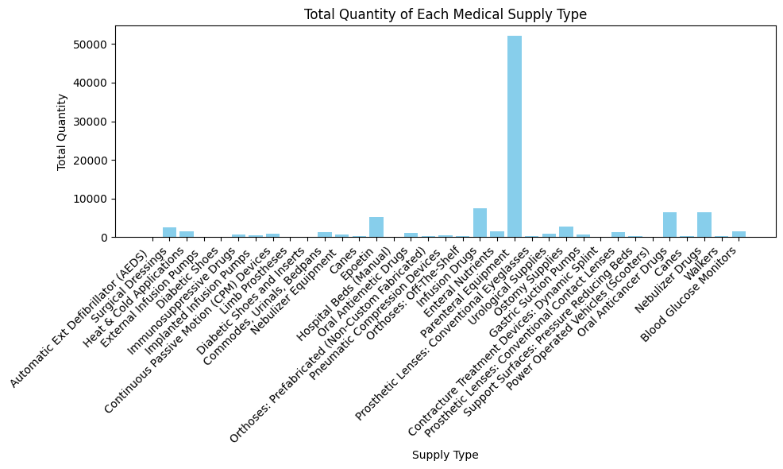

```python
#sdb
import matplotlib.pyplot as plt

pipeline_supply_quantity = [
    {"$group": {"_id": "$supplieslist", "total_quantity": {"$sum": "$Quantity"}}}
]

supply_quantity_result = db.aggregate(pipeline_supply_quantity)

supply_types = []
total_quantities = []

for result in supply_quantity_result:
    supply_types.append(result['_id'])
    total_quantities.append(result['total_quantity'])

plt.figure(figsize=(10, 6))
plt.bar(supply_types, total_quantities, color='skyblue')
plt.xlabel('Supply Type')
plt.ylabel('Total Quantity')
plt.title('Total Quantity of Each Medical Supply Type')
plt.xticks(rotation=45, ha='right')
plt.tight_layout()
plt.show()
```

# Pie Chart of Supply Distribution by Category:

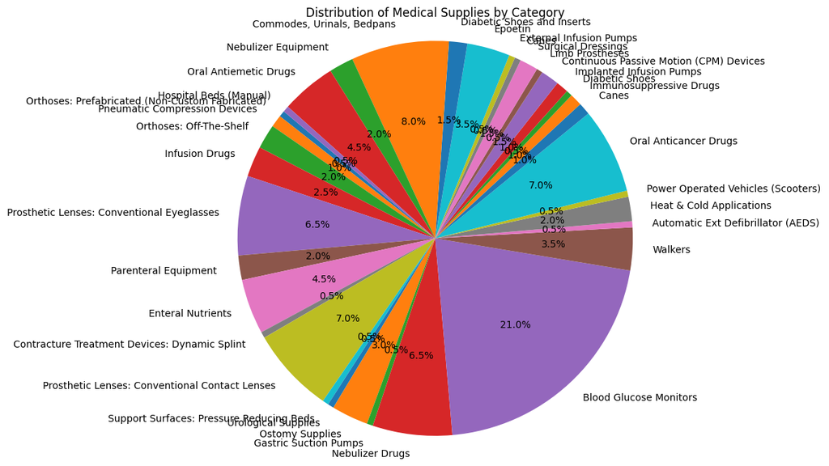

```python
#sdb
pipeline_supply_category = [
    {"$group": {"_id": "$supplieslist", "count": {"$sum": 1}}}
]

supply_category_result = db.aggregate(pipeline_supply_category)

labels = []
counts = []

for result in supply_category_result:
    labels.append(result['_id'])
    counts.append(result['count'])

plt.figure(figsize=(8, 8))
plt.pie(counts, labels=labels, autopct='%1.1f%%', startangle=140)
plt.title('Distribution of Medical Supplies by Category')
plt.axis('equal')
plt.show()
```

# Line Chart of Epoetin Quantity Over Time:

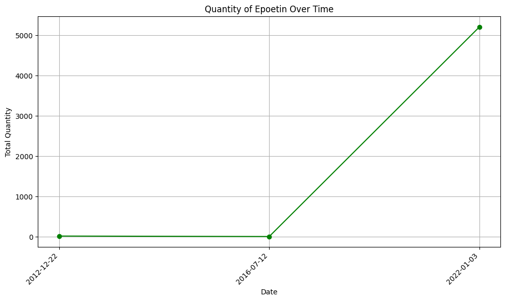

```python
#sdb

supply_name = "Epoetin"

pipeline_supply_quantity_over_time = [
    {"$match": {"supplieslist": supply_name}},
    {"$group": {"_id": {"$dateToString": {"format": "%Y-%m-%d", "date": "$Date_Purchased"}}, "total_quantity": {"$sum": "$Quantity"}}},
    {"$sort": {"_id": 1}}
]

supply_quantity_over_time_result = db.aggregate(pipeline_supply_quantity_over_time)

dates = []
quantities = []

for result in supply_quantity_over_time_result:
    dates.append(result['_id'])
    quantities.append(result['total_quantity'])

plt.figure(figsize=(10, 6))
plt.plot(dates, quantities, marker='o', color='green', linestyle='-')
plt.xlabel('Date')
plt.ylabel('Total Quantity')
plt.title('Quantity of {} Over Time'.format(supply_name))
plt.xticks(rotation=45, ha='right')
plt.tight_layout()
plt.grid(True)
plt.show()
```

# Histogram of Infusion Drug Prices

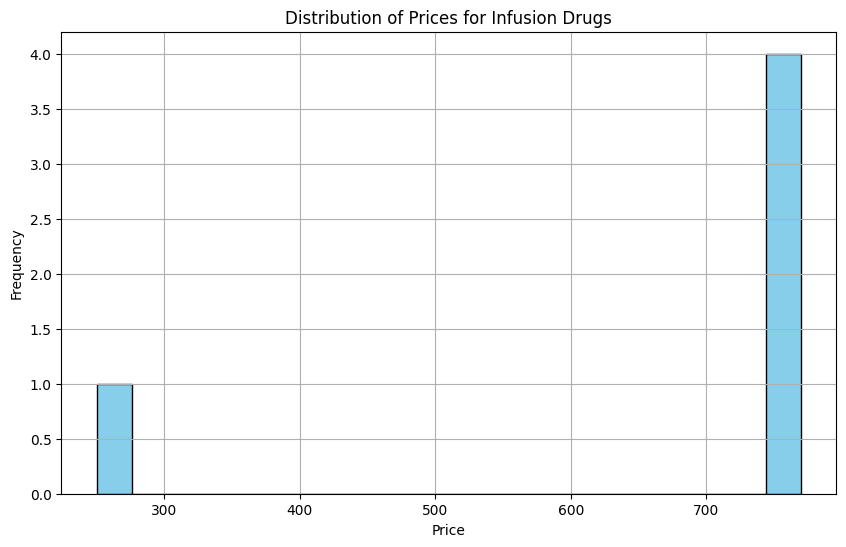

```python
#nr

supply_name = "Infusion Drugs"

pipeline_supply_prices = [
    {"$match": {"supplieslist": supply_name}},
    {"$group": {"_id": None, "prices": {"$push": "$Unit_Price"}}}
]

supply_prices_result = db.aggregate(pipeline_supply_prices)
for result in supply_prices_result:
    prices = result['prices']

plt.figure(figsize=(10, 6))
plt.hist(prices, bins=20, color='skyblue', edgecolor='black')
plt.xlabel('Price')
plt.ylabel('Frequency')
plt.title('Distribution of Prices for {}'.format(supply_name))
plt.grid(True)
plt.show()
```

# Total Cost of Supplies Over Time

[figure not shown]

```python
#nr
pipeline_total_cost_over_time = [
    {"$group": {"_id": {"$dateToString": {"format": "%Y-%m-%d", "date": "$Date_Purchased"}}, "total_cost": {"$sum": {"$multiply": ["$Unit_Price", "$Quantity"]}}}},
    {"$sort": {"_id": 1}}
]

total_cost_over_time_result = db.aggregate(pipeline_total_cost_over_time)

dates = []
total_costs = []

for result in total_cost_over_time_result:
    dates.append(result['_id'])
    total_costs.append(result['total_cost'])

plt.figure(figsize=(60, 20))
plt.plot(dates, total_costs, marker='o', color='skyblue')
plt.xlabel('Date')
plt.ylabel('Total Cost')
plt.title('Total Cost of Supplies Over Time')
plt.xticks(rotation=45, ha='right')
plt.grid(True)
plt.show()
```